# Assignment - Week 06

Flurin Schindele

2026-03-31

```r
suppressPackageStartupMessages({
  library(ggplot2)
  library(dplyr)
  library(AnnotationHub)
  library(GenomicRanges)
  library(memes) # for the meme-based methods
  library(motifmatchr) # for scanning sequences for matches of given motifs
  library(Biostrings) # for Ωhandling sequences
  library(MotifDb) # database of motifs
  library(TFBSTools) # for handling some motif formats
  library(universalmotif) # for converting motifs to various formats
  library(GenomeInfoDb)
  library(Rsamtools)
})
```

```
## See system.file("LICENSE", package="MotifDb") for use restrictions.
```

```r
ah <- AnnotationHub()
options(meme_bin = "/opt/meme/bin/")
```

# Download REST ChIP-seq peaks

We are working with ChIP-seq peak data for the REST transcription factor in mouse. The data consists of narrow peaks from the ENCODE project.

```r
dir.create("./data", showWarnings = FALSE)
download.file(
  "https://www.encodeproject.org/files/ENCFF368VWJ/@@download/ENCFF368VWJ.bed.gz",
  "data/REST_ChIPseq_peaks-ENCFF368VWJ.bed.gz",
  mode="wb"
)
```

We load the peaks and convert sequence level styles to UCSC format. For computational efficiency, we focus on chromosome 1 for some analyses.

```r
peaks <- rtracklayer::import("data/REST_ChIPseq_peaks-ENCFF368VWJ.bed.gz", format="NarrowPeak")
seqlevelsStyle(peaks) <- "UCSC"
peaks_chr1 <- peaks[seqnames(peaks)=="chr1"]
```

```r
query_results <- AnnotationHub::query(ah, c("Mus musculus", "mm10", "2bit"))
genome <- ah[[tail(query_results$ah_id)[1]]]
```

```
## loading from cache
```

```
## require("rtracklayer")
```

```r
if (!file.exists("data/mm10.fa")) {
  options(timeout = max(600, getOption("timeout")))
  download.file(
    "https://hgdownload.soe.ucsc.edu/goldenPath/mm10/bigZips/mm10.fa.gz",
    "data/mm10.fa.gz"
  )
  R.utils::gunzip("data/mm10.fa.gz", destname="data/mm10.fa")
  Rsamtools::indexFa("data/mm10.fa")
} else {
  message("FASTA file already exists, skipping download.")
}
```

```
## FASTA file already exists, skipping download.
```

```r
fasta_path <- "data/mm10.fa"
```

# Motif detection

We retrieve the REST motif position weight matrix from the HOCOMOCO v10 database. This motif represents the DNA binding preference of the REST transcription factor.

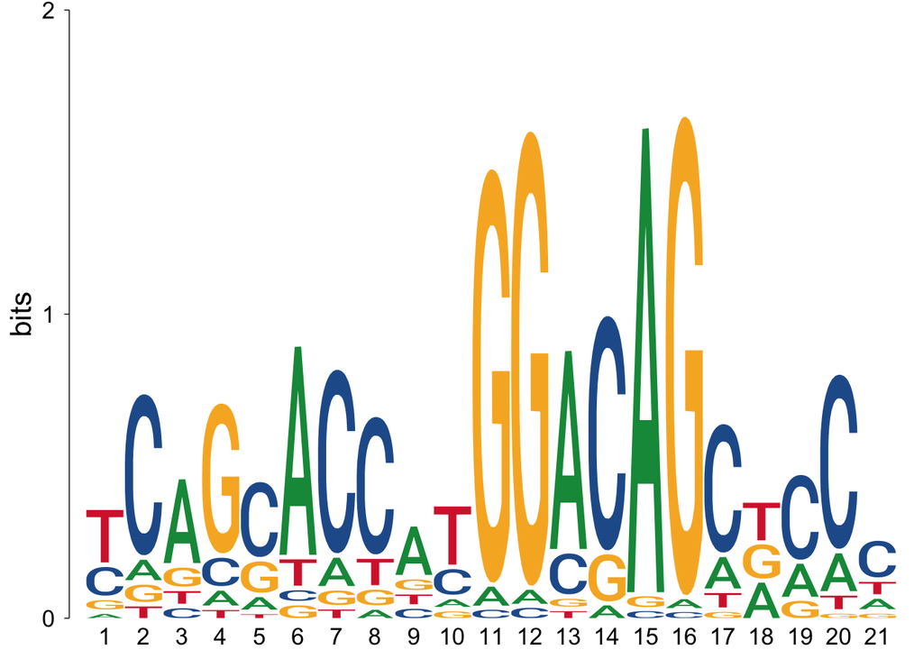

```r
mouse_motifs <- query(MotifDb, c("Mmusculus", "HOCOMOCOv10"))
rest_motif <- mouse_motifs[grep("REST", names(mouse_motifs))]

view_motifs(rest_motif)
```

# Motif Enrichment

```r
quantile(width(peaks_chr1))
```

```
##   0%  25%  50%  75% 100%
##   64  136  136  136  250
```

```r
peak_centers <- resize(peaks, fix="center", width=100)
quantile(width(peak_centers))
```

```
##   0%  25%  50%  75% 100%
##  100  100  100  100  100
```

We extract the DNA sequences for these centered peak regions from the genome.

```r
peak_seqs <- memes::get_sequence(peak_centers, genome)
names(peak_seqs) <- paste0("seq_", seq_along(peak_seqs))
writeXStringSet(peak_seqs, file = "data/peaks_centered_100bp.fa")
head(peak_seqs, 5)
```

```
## DNAStringSet object of length 5:
##     width seq                                               names
## [1]   100 CAGGTCATCTGCTCTATGGCGCC...TGGCTTCCAGGATGCTGACCTAC seq_1
## [2]   100 TGAGGCTGTTGGCTGAAAGGAGT...TGGAGGATGGGCACCAAGGATAG seq_2
## [3]   100 GGCCGGTCAGGGAGGGAATCACA...GGGAGGGCAACGGAAGGTCTTAA seq_3
## [4]   100 GTCGCTACCGCGGACAGCTCCCA...CATCTGTAGGCTTGAGATGCTGT seq_4
## [5]   100 CAGCTGGTGCTGTCCATGTGGGA...CTGTTCTGCTCACACACACACCA seq_5
```

We run AME (Analysis of Motif Enrichment) to test which motifs are enriched in our peak sequences. AME compares motif occurrence in peak sequences against a control to identify significantly enriched motifs.

```r
if (!file.exists("data/ame_results.rds")) {
  ame <- memes::runAme(peak_seqs, database=convert_motifs(mouse_motifs), silent=TRUE)
  saveRDS(ame, "data/ame_results.rds")
} else {
  print("Loading AME results from file...")
  ame <- readRDS("data/ame_results.rds")
}
```

```
## [1] "Loading AME results from file..."
```

```r
head(ame)
```

| rank | motif_db | motif_id | motif_alt_id | consensus | pvalue | adj.pvalue | evalue | tests | fasta_max | pos | neg | pwm_min | tp | tp_percent | fp | fp_percent |
| --- | --- | --- | --- | --- | --- | --- | --- | --- | --- | --- | --- | --- | --- | --- | --- | --- |
| 1 | /var/folders/t2/68ltn7ds36523gbx2tkkj4zh0000gn/T//RtmpFOsJLe/321 | REST | REST_MOUSE.H10MO.A | YCAGCACCATGGACAGCDCCC | 1.02e-305 | 2.15e-305 | 9.14e-305 | 2103 | 3555 | 3555 | 3555 | 13.10 | 1662 | 46.75 | 41 | 1.15 |
| 2 | /var/folders/t2/68ltn7ds36523gbx2tkkj4zh0000gn/T//RtmpFOsJLe/199 | MAF | MAF_MOUSE.H10MO.B | KTGCTGAC | 4.19e-133 | 1.26e-129 | 5.36e-127 | 3004 | 3555 | 3555 | 3555 | 4.69 | 1071 | 30.13 | 280 | 7.88 |
| 3 | /var/folders/t2/68ltn7ds36523gbx2tkkj4zh0000gn/T//RtmpFOsJLe/319 | RELB | RELB_MOUSE.H10MO.C | RGGGRMTTTCCM | 1.80e-67 | 2.17e-64 | 9.23e-62 | 1201 | 3555 | 3555 | 3555 | 3.44 | 580 | 16.32 | 149 | 4.19 |
| 4 | /var/folders/t2/68ltn7ds36523gbx2tkkj4zh0000gn/T//RtmpFOsJLe/195 | MAFB | MAFB_MOUSE.H10MO.D | WGCTGACDS | 6.60e-51 | 2.12e-47 | 9.04e-45 | 3212 | 3555 | 3555 | 3555 | 2.19 | 1287 | 36.20 | 721 | 20.28 |
| 5 | /var/folders/t2/68ltn7ds36523gbx2tkkj4zh0000gn/T//RtmpFOsJLe/308 | PRGR | PRGR_MOUSE.H10MO.S | AGAACAB | 6.46e-41 | 1.50e-37 | 6.39e-35 | 2323 | 3555 | 3555 | 3555 | 1.04 | 1425 | 40.08 | 898 | 25.26 |
| 6 | /var/folders/t2/68ltn7ds36523gbx2tkkj4zh0000gn/T//RtmpFOsJLe/375 | TBX20 | TBX20_MOUSE.H10MO.C | RRGTGNTGACAGS | 1.73e-34 | 2.98e-31 | 1.27e-28 | 1721 | 3555 | 3555 | 3555 | 1.30 | 996 | 28.02 | 571 | 16.06 |

The enrichment plot shows motifs by their fold-enrichment and statistical significance. The REST motif is the most enriched motifs, as expected for REST ChIP-seq peaks. The x-axis shows fold-enrichment of true positives over false positives, while the y-axis shows statistical significance.

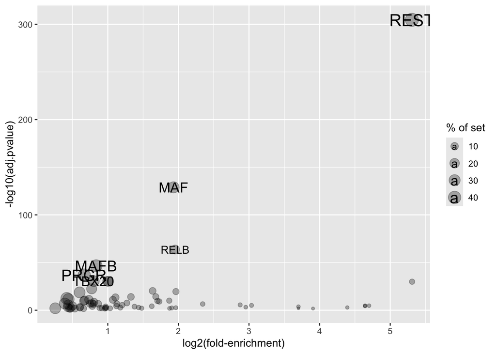

```r
ggplot(ame, aes(log2((1+tp)/(1+fp)), -log10(adj.pvalue), size=tp_percent)) +
  geom_point(alpha=0.3) + geom_text(aes(label=motif_id), data=head(ame)) +
  labs(x="log2(fold-enrichment)", size="% of set")
```

## Visualizing Motif Location Centrimo

Centrimo identifies the central enrichment of motifs relative to peak centers. If motifs are truly associated with transcription factor binding, they should be enriched at the peak center. We can use Centrimo to analyze the spatial distribution of REST motifs within our peak regions.

```bash
curl -L -o data/H14CORE_meme_format.meme https://hocomoco14.autosome.org/final_bundle/hocomoco14/H14CORE/formatted_motifs/H14CORE_meme_format.meme

/opt/meme/bin/centrimo -oc data/centrimo_results --verbosity 1 data/peaks_centered_100bp.fa data/H14CORE_meme_format.meme

awk '/MOTIF.*REST/{print; flag=1; next} /DB/ && flag{flag=0} flag' data/centrimo_results/site_counts.txt > data/centrimo_results/rest_counts.txt
```

```
##   % Total    % Received % Xferd  Average Speed   Time    Time     Time  Current
##                                  Dload  Upload   Total   Spent    Left  Speed
##   0     0    0     0    0     0      0      0 --:--:-- --:--:-- --:--:--     0100 1757k  100 1757k    0     0  7039k      0 --:--:-- --:--:-- --:--:-- 7057k
```

The resulting html file can be found under `data/centrimo_results/centrimo.html`.

We can also visualize the distribution of the REST motif only using the `rest_counts.txt` file we extracted from the Centrimo output. The plot shows a strong central enrichment of REST motifs, with a peak around position 0 (the peak center). This confirms that REST motifs are preferentially located at the center of ChIP-seq peaks, which again hints at genuine binding sites. I believe that the higher the ChIP-seq resolution, the narrower the peaks. Our curve looks pretty rough and noisy compared to the Centrimo output, because we did not perform any smoothing (Centrimo does sliding-window averaging).

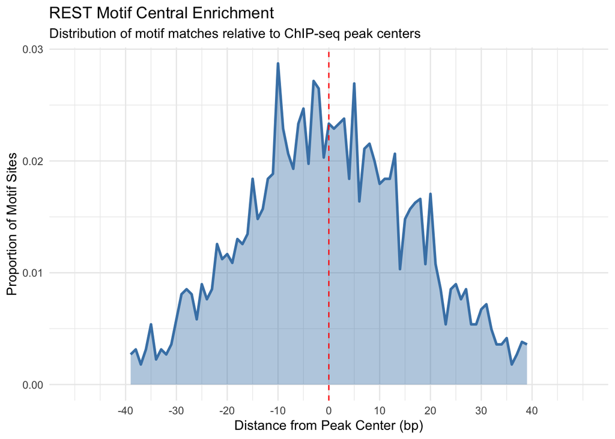

```r
data <- read.table("data/centrimo_results/rest_counts.txt", skip = 1, header = FALSE, col.names = c("position", "count"))
data$prop <- data$count / sum(data$count)
# 2. Create the plot
ggplot(data, aes(x = position, y = prop)) +
  geom_area(fill = "steelblue", alpha = 0.4) + # Fills the area under the curve
  geom_line(color = "steelblue", size = 1) +  # Adds a sharp line on top
  theme_minimal() +
  geom_vline(xintercept = 0, linetype = "dashed", color = "red") + # Mark the center
  labs(
    title = "REST Motif Central Enrichment",
    subtitle = "Distribution of motif matches relative to ChIP-seq peak centers",
    x = "Distance from Peak Center (bp)",
    y = "Proportion of Motif Sites"
  ) +
  coord_cartesian(xlim = c(-50, 50)) +
  scale_x_continuous(breaks = seq(-40, 40, by = 10))
```

# Motif Matching

## Finding Motifs in the Mouse Genome

We use motifmatchr to scan the entire mouse genome for sequences matching the REST motif. This creates a reference set of all potential REST binding sites based on sequence alone.

```r
if (!file.exists("data/motifs_genome.rds")) {

  # 1. Create a reference to the FASTA file

  genome_fa <- FaFile(fasta_path)

  # 2. Extract chromosome names and lengths to create a GRanges object
  genome_ranges <- as(seqinfo(genome_fa), "GRanges")

  # 3. Convert motif
  target_pwm <- convert_motifs(rest_motif, class="TFBSTools-PWMatrix")[[1]]

  # 4. Run matchMotifs
  # subject = GRanges defining the regions (the whole chromosomes)
  # genome = FaFile containing the actual DNA sequence
  motifs_genome_raw <- motifmatchr::matchMotifs(
    pwms = target_pwm,
    subject = genome_ranges,
    genome = genome_fa,
    out = "positions"
  )

  # 5. Extract the GRanges for the motif
  motifs_genome <- motifs_genome_raw[[1]]

  saveRDS(motifs_genome, "data/motifs_genome.rds")

} else {
  message("Loading genome-wide motifmatchr results from file...")
  motifs_genome <- readRDS("data/motifs_genome.rds")
}
```

```
## Loading genome-wide motifmatchr results from file...
```

```r
head(motifs_genome)
```

```
## GRanges object with 6 ranges and 1 metadata column:
##       seqnames          ranges strand |     score
##          <Rle>       <IRanges>  <Rle> | <numeric>
##   [1]     chr1 3009026-3009046      + |  11.46892
##   [2]     chr1 3021779-3021799      + |  10.18544
##   [3]     chr1 3022783-3022803      + |  10.96791
##   [4]     chr1 3024885-3024905      + |   8.98931
##   [5]     chr1 3029113-3029133      + |   8.57723
##   [6]     chr1 3037640-3037660      + |   9.02617
##   -------
##   seqinfo: 66 sequences from an unspecified genome; no seqlengths
```

The score distribution shows the quality of motif matches across the genome. Higher scores indicate better matches to the REST consensus sequence.

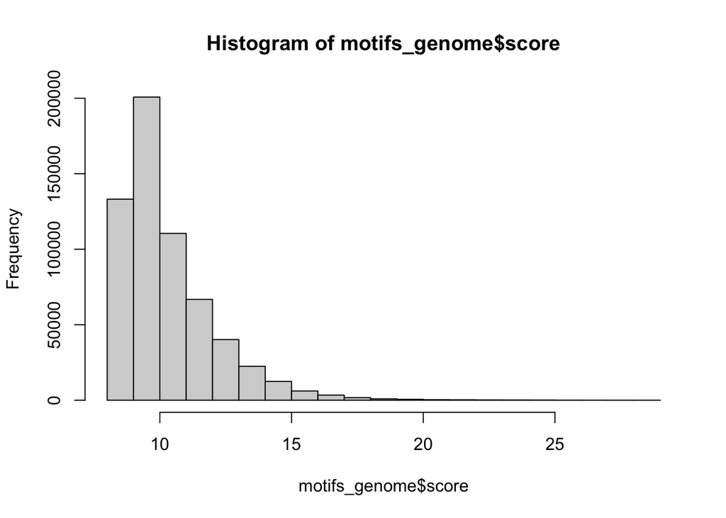

```r
hist(motifs_genome$score)
```

```r
table(overlapsAny(peaks, motifs_genome))
```

```
##
## FALSE  TRUE
##  1660  1895
```

## Finding Motifs in the ChIP-seq Peaks

### Using FIMO

FIMO (Find Individual Motif Occurrences) scans peak sequences for REST motif matches. It reports the position and score of each match, allowing us to identify which peaks contain the motif. As far as I understand, it should behave quite similarly to motifmatchr but we will compare below.

```r
if (!file.exists("data/fimo_peaks_results.rds")) {
  fimo_peaks <- memes::runFimo(
    sequences = peak_seqs,
    motifs = convert_motifs(rest_motif),
    parse_genomic_coord = FALSE
  )
  saveRDS(fimo_peaks, "data/fimo_peaks_results.rds")
} else {
  print("Loading FIMO results from file...")
  fimo_peaks <- readRDS("data/fimo_peaks_results.rds")
}
```

```
## [1] "Loading FIMO results from file..."
```

```r
head(fimo_peaks)
```

```
## GRanges object with 6 ranges and 6 metadata columns:
##       seqnames    ranges strand |    motif_id       motif_alt_id     score
##          <Rle> <IRanges>  <Rle> | <character>        <character> <numeric>
##   [1]    seq_1     22-42      + |        REST REST_MOUSE.H10MO.A   24.3333
##   [2]    seq_1     43-63      + |        REST REST_MOUSE.H10MO.A   22.7424
##   [3]    seq_2     43-63      - |        REST REST_MOUSE.H10MO.A   28.8788
##   [4]    seq_3     27-47      + |        REST REST_MOUSE.H10MO.A   27.0152
##   [5]    seq_3     51-71      - |        REST REST_MOUSE.H10MO.A   21.0758
##   [6]    seq_4      2-22      + |        REST REST_MOUSE.H10MO.A   19.5152
##          pvalue    qvalue      matched_sequence
##       <numeric> <numeric>           <character>
##   [1]  1.19e-09        NA CCAGCACCAAGGACAGCACCG
##   [2]  6.36e-09        NA CAAGCACCAAGGACAGCACCA
##   [3]  1.82e-12        NA TCAGCACCACGGACAGCGCCC
##   [4]  3.98e-11        NA TCAGGACCGTGGACAGCACCC
##   [5]  3.04e-08        NA TCAGCACCAAGGACAGAGGCG
##   [6]  1.16e-07        NA TCGCTACCGCGGACAGCTCCC
##   -------
##   seqinfo: 1929 sequences from an unspecified genome; no seqlengths
```

```r
message("Number of peaks with FIMO match: ", length(unique(fimo_peaks)))
```

```
## Number of peaks with FIMO match: 2162
```

The score distribution for FIMO matches shows predominantly high-scoring motif occurrences within ChIP-seq peaks.

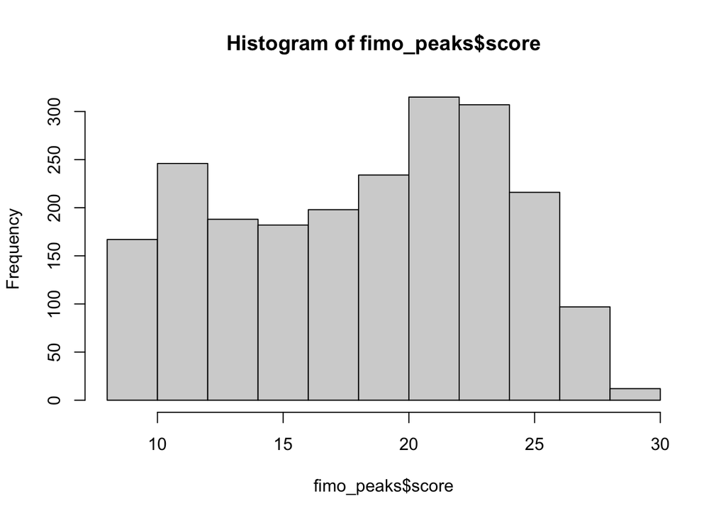

```r
hist(fimo_peaks$score)
```

### Using motifmatchr

As an alternative approach, we use motifmatchr to identify REST motifs within ChIP-seq peaks.

```r
if (!file.exists("data/motifmatchr_peaks.rds")) {
  genome_fa <- FaFile(fasta_path)

  motifmatchr_peaks <- motifmatchr::matchMotifs(
    pwms = convert_motifs(rest_motif, class="TFBSTools-PWMatrix")[[1]],
    subject = peaks,
    genome = genome_fa,
    out = "positions"
  )[[1]]
  saveRDS(motifmatchr_peaks, "data/motifmatchr_peaks.rds")
} else {
  print("Loading motifmatchr results from file...")
  motifmatchr_peaks <- readRDS("data/motifmatchr_peaks.rds")
}
```

```
## [1] "Loading motifmatchr results from file..."
```

```r
head(motifmatchr_peaks)
```

```
## GRanges object with 6 ranges and 1 metadata column:
##       seqnames            ranges strand |     score
##          <Rle>         <IRanges>  <Rle> | <numeric>
##   [1]     chr2 33018215-33018235      + |   25.6859
##   [2]     chr2 33018236-33018256      + |   23.0344
##   [3]     chr9 56738489-56738509      + |   13.5817
##   [4]     chr9 56738447-56738467      - |   30.7435
##   [5]     chr9 21950501-21950521      + |   28.3548
##   [6]     chr9 21950525-21950545      - |   21.9139
##   -------
##   seqinfo: 20 sequences from an unspecified genome; no seqlengths
```

```r
message("Number of peaks with motifmatchr match: ", length(motifmatchr_peaks))
```

```
## Number of peaks with motifmatchr match: 1828
```

We can compare the score distributions between FIMO and motifmatchr. Both methods identify similar high-quality matches, though FIMO finds more motif instances including lower scores. This difference could be due to different thresholds for motif reporting but I did not check.

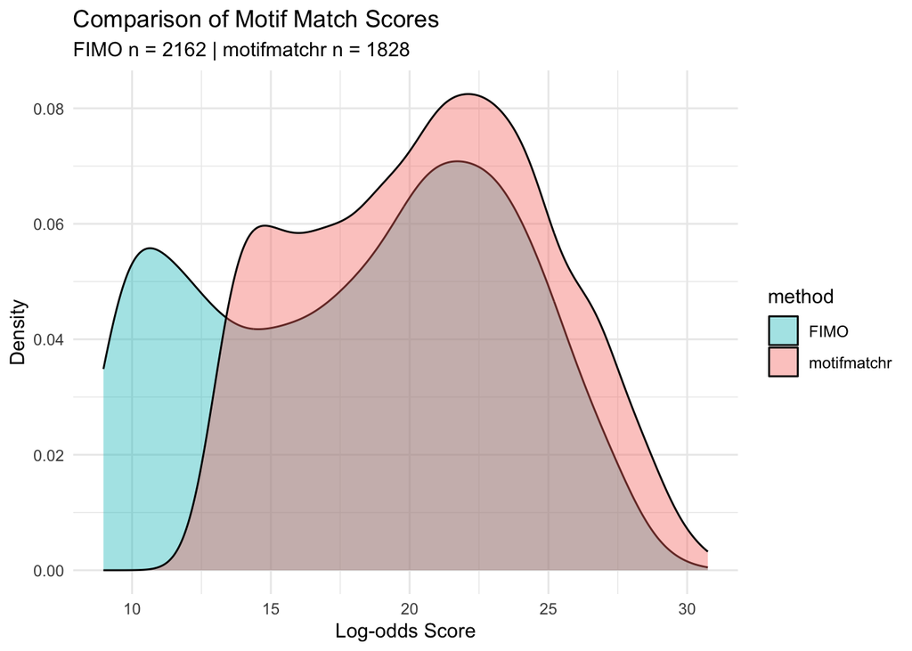

```r
# 1. Extract scores and label the source
df_fimo <- data.frame(
  score = fimo_peaks$score,
  method = "FIMO"
)

df_motifmatchr <- data.frame(
  score = motifmatchr_peaks$score,
  method = "motifmatchr"
)

# 2. Combine into one data frame for plotting
plot_data <- rbind(df_fimo, df_motifmatchr)

# 3. Create the plot
# Using geom_density is often cleaner than a histogram for comparing two distributions
ggplot(plot_data, aes(x = score, fill = method)) +
  geom_density(alpha = 0.4) +
  theme_minimal() +
  labs(
    title = "Comparison of Motif Match Scores",
    subtitle = paste("FIMO n =", nrow(df_fimo), "| motifmatchr n =", nrow(df_motifmatchr)),
    x = "Log-odds Score",
    y = "Density"
  ) +
  scale_fill_manual(values = c("FIMO" = "#00BFC4", "motifmatchr" = "#F8766D"))
```

# Motif Discovery

STREME (Sensitive, Thorough, Rapid, Enriched Motif Elicitation) performs de novo motif discovery. Rather than searching for known motifs, it identifies enriched sequence patterns directly from the data. We compare peak sequences to shuffled controls (preserving dinucleotide frequencies) to find significantly enriched motifs.

```r
if (!file.exists("data/streme_results.rds")) {
  streme <- memes::runStreme(
   input = peak_seqs,
   control = "shuffle", # the peak sequences will be compared to shuffled versions (with same dinucleotide frequency)
   nmotifs=5 # determines how many motifs we will try to find
  )
  saveRDS(streme, "data/streme_results.rds")
} else {
  print("Loading STREME results from file...")
  streme <- readRDS("data/streme_results.rds")
}
```

```
## [1] "Loading STREME results from file..."
```

```r
streme[,c("consensus", "pval", "nsites")]
```

|  | consensus | pval | nsites |
| --- | --- | --- | --- |
| m01_CTGTCCATGGTGCT | CTGTCCATGGTGCT | 8.4e-52 | 1464 |
| m02_CTGGACAGCKCCH | CTGGACAGCKCCN | 7.6e-18 | 685 |
| m03_GGTGCTGAAA | GGTGCTGAAA | 6.1e-05 | 238 |
| m04_AAGATGGCGGCGGCS | RAGATGGCGGCGGCS | 1.9e-03 | 180 |
| m05_CCCTCCCCCR | CCCTCCCCCR | 4.2e-01 | 205 |

We visualize the top discovered motif alongside the known REST motif. The de novo discovered motif closely matches the known REST binding motif. Few positions differ, but the general pattern is the same.

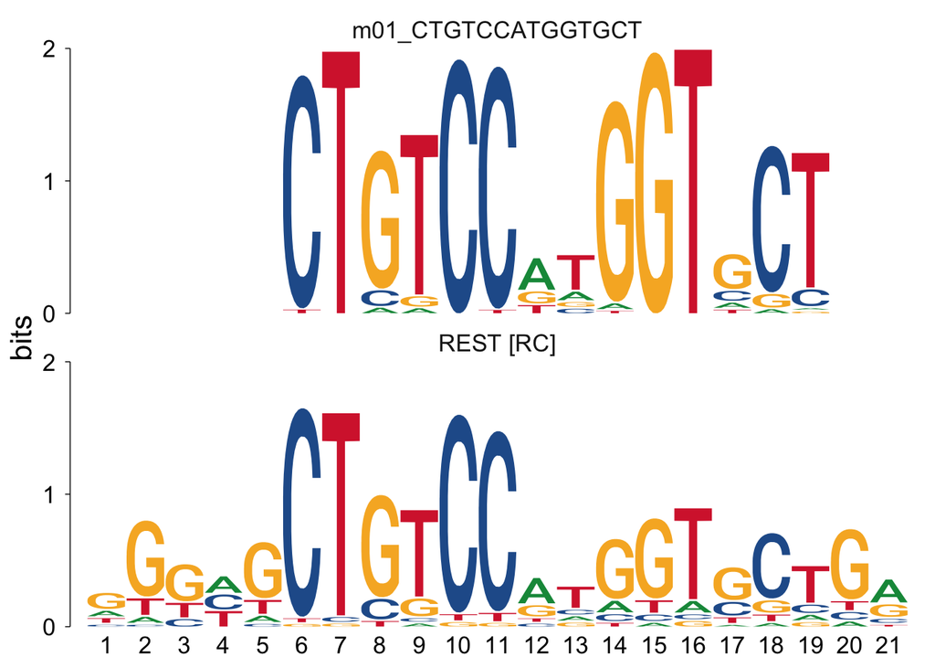

```r
view_motifs(c(to_list(streme[1,]), convert_motifs(rest_motif)))
```

# Results